# sexDifferences

Melanie Smith

10/02/2019

# Load required libraries

```r
library(plyr)
library(reshape2)
library(dplyr)
library(tidyverse)
library(pander)
library(magrittr)
library(edgeR)
library(RColorBrewer)
library(limma)
library(ggplot2)
library(pheatmap)
library(Rmisc)
library(EDASeq)
library(beeswarm)
library(here)
library(xtable)
library(readxl)
library(biomaRt)
library(org.Hs.eg.db)
library(pander)
```

# Load user defined functions

```r
source(here("R", "getTopMiRs.R"))
source(here("R", "expressionByWeek.R"))

`%notin%` <- Negate(`%in%`)

recur_factorial <- function(n) {
if(n <= 1) {
return(1)
} else {
return(n * recur_factorial(n-1))
}
}
```

The purpose of this script is to investigate differences between male and female bearing pregnancies (placenta)

## Lets talk about sex baby!

# Import Counts and Sample Data

- This step imports the raw placenta counts data and the sample data
- PAC0071 and PAC0131 removed due to low reads
- PAC0041, PAC0039, PAC0045, PAC0008, PAC0035, PAC0024, PAC0034, PAC0006 removed due to decidual contamination
- The counts have not been normalised or filtered for low expression
- These are raw counts and not cpm (or similar)

```r
# import raw miRNA counts table
countsPlacenta <- read.table(here("rawData", "counts_placenta.tsv"),
                             sep = "\t",
                             header = TRUE,
                             row.names = "mirna")


# remove the "_merge_R1" from the sample name for simplification
names(countsPlacenta) <- sub("_merge_R1","",names(countsPlacenta))

# remove the "Q" prefix from the sample names so I can replace with PAC
names(countsPlacenta) <- sub("Q","",names(countsPlacenta))

# Create a df of sample names from the counts table, then add PAC prefix and pad to 7 characters
countsPlacentaNames <- data.frame(names(countsPlacenta)) %>%
  mutate(names.countsPlacenta. = paste0("PAC",stringr::str_pad(names.countsPlacenta., width = 4, pad = "0")))

# convert back to a vector so I can overwrite the colnames in the counts table
countsPlacentaNames <- countsPlacentaNames[,]

# replace the old sample names with the new names (PACXXXX)
names(countsPlacenta) <- countsPlacentaNames

# ensure the columns are ordered by assending sample name
countsPlacenta <- countsPlacenta[,order(colnames(countsPlacenta),decreasing=FALSE)]

countsPlacenta_noHV <- countsPlacenta %>%
  # remove poorly sequenced samples
  dplyr::select(., -c(PAC0071,PAC0131)) %>%
  # remove samples failing tests for purity
  dplyr::select(., -c(PAC0041, PAC0039, PAC0045, PAC0008, PAC0035, PAC0024, PAC0034, PAC0006))

samples_noHV <- readRDS(here("cleanData", "samples_noHV.rds")) %>%
  dplyr::filter(., !grepl('PAC0131', samplename))  %>% # remove PAC0131 - low reads
  dplyr::filter(., !grepl('PAC0071', samplename)) # remove PAC0071 - low reads

samples <- readRDS(here("cleanData/samples.rds"))
```

# Filter sequencing noise

- Here any individual observation with less than five counts is considered to be sequencing noise and is reduced to zero and removed by filtering.
- Counts less than 5 reduced to 0
- Logic check and record how many miRs will be filtered
- Filter to remove miRs with zero counts in all samples

```r
# remove multimapped miRNA with identical mature sequences
identicalMature <- c("hsa-miR-199b-3p", "hsa-miR-365b-3p", "hsa-miR-517b-3p", "hsa-miR-518d-5p", "hsa-miR-520c-5p", "hsa-miR-526a", "hsa-miR-518e-5p", "hsa-miR-519b-5p", "hsa-miR-522-5p", "hsa-miR-523-5p", "hsa-miR-519c-5p")

# here the mature miRNA with the lowest number is retained
countsPlacenta_noHV <- countsPlacenta_noHV %>%
  subset(., rownames(countsPlacenta_noHV) %notin% identicalMature)

# reduce any individual count less than five to zero
countsPlacenta_noHV[countsPlacenta_noHV < 5] <- 0

# check to establish if any miRNA have no expression across all samples
table(rowSums(countsPlacenta_noHV == 0) == 86)
```

```
##
## FALSE  TRUE
##  1420   610
```

```r
# remove miRNAs with zero counts in all samples
countsPlacenta_noHV <- countsPlacenta_noHV[ rowSums(countsPlacenta_noHV)!=0, ]
```

# Establish DGEList object

The counts and samples data can now be combined into a single list object for use in differential expression analysis downstream.

```r
# new df of miRNA names for DGEList object
genes <- as.character(rownames(countsPlacenta_noHV)) %>%
  as.data.frame() %>%
  set_colnames("SYMBOL")

# new DGEList object for differential expression analysis
DGEList_placenta_noHV <- DGEList(counts=countsPlacenta_noHV,
                                 samples=samples_noHV,
                                 genes = genes)
```

# Plot the distribution of miRs before normalisation

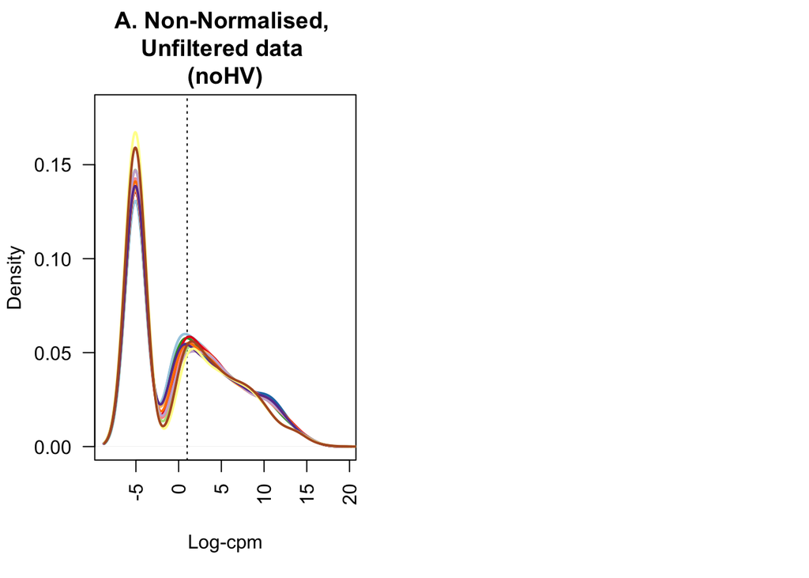

# TMM normalisation of libraries

Before differential expression analysis the sample libraries need to be normalised to account for differences in initial library size.  
Normalising the libraries allows for the direct comparison between samples.  
Here the Trimmed Mean of M Values method is used.  
Prior to normalisation the placenta libraries are within a similar range with and centered around 0-1 CPM (log2)

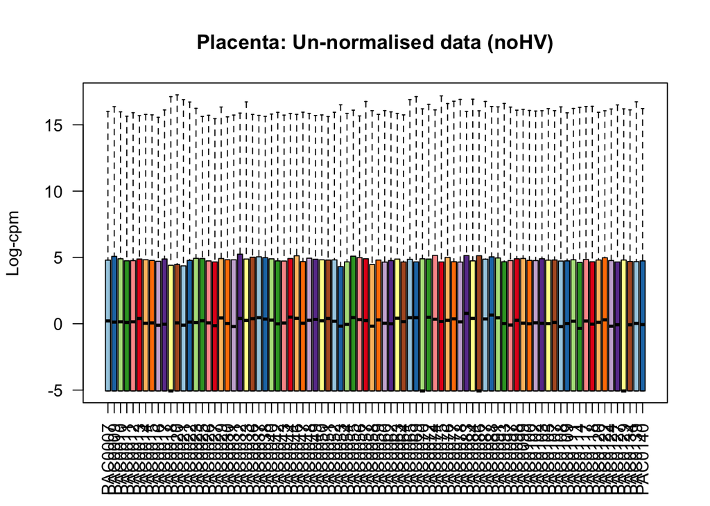

# Filter biological noise and plot

```r
# calculate the cpm value of a read count of 10 given the mean library size (to be used in the keep.genes)
cpm(10, mean(DGEList_placenta_noHV$samples$lib.size))
```

```
##          [,1]
## [1,] 1.195957
```

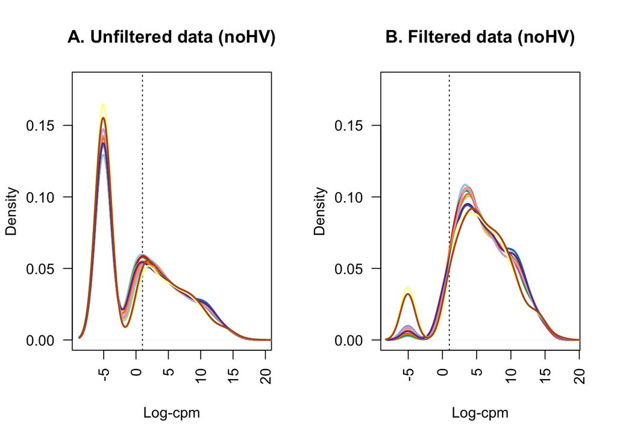

```r
# returns a value of 1.05689

# new df of unfiltered cpm for the reduced DGEList
rawCpm_placenta_noHV <- cpm(DGEList_placenta_noHV)

# new df of unfiltered log 2 cpm for the reduced DGEList
rawlcpm_placenta_noHV <- cpm(DGEList_placenta_noHV, log = TRUE)

# remove low expressed genes (22 hypoxic = smaller group)
keep.exprs_noHV <- rowSums(rawCpm_placenta_noHV > 2.5) >= 29
DGEList_placenta_noHV <- DGEList_placenta_noHV[keep.exprs_noHV,, keep.lib.sizes = FALSE]

## The density of log-CPM values for pre-filtered data
# (A) and post-filtered data
# (B) are shown for each sample.
## Dotted vertical lines mark the log-CPM of 1 threshold
# (equivalent to a CPM value of 2).

nsamples_noHV <- ncol(DGEList_placenta_noHV)
col <- brewer.pal(nsamples_noHV, "Paired")
par(mfrow=c(1,2))
#pdf("preFilterPlacenta.pdf")
plot(density(rawlcpm_placenta_noHV[,1]), col = col[1], lwd = 2, ylim = c(0, 0.18), las = 2,
  main = "", xlab = "")
title(main = "A. Unfiltered data (noHV)", xlab = "Log-cpm")
abline(v = 1, lty = 3)
for (i in 1:nsamples_noHV){
  den <- density(rawlcpm_placenta_noHV[,i])
  lines(den$x, den$y, col = col[i], lwd = 2)
}
#legend("topright", legend = samples$samplename, text.col = col, bty = "n")
#dev.off()
lcpm_noHV <- cpm(DGEList_placenta_noHV, log=TRUE)
#pdf("filteredPlacenta.pdf")
plot(density(lcpm_noHV[,1]), col = col[1], lwd = 2, ylim = c(0, 0.18), las = 2,
  main = "", xlab = "")
title(main = "B. Filtered data (noHV)", xlab = "Log-cpm")
abline(v = 1, lty = 3)
for (i in 1:nsamples_noHV){
  den <- density(lcpm_noHV[,i])
lines(den$x, den$y, col = col[i], lwd = 2)
}
```

```r
#legend("topright", legend=samples$samplename, text.col=col, bty="n")
#dev.off ()
par(mfrow=c(1,1))

# save the cpm table
saveRDS(cpm, here("cleanData", "cpm.rds"))

# save the filtered, normalised DGEList object
saveRDS(DGEList_placenta_noHV, here("cleanData/DGEList_placenta_noHV.rds"))
```

## Plot filtered library sizes against total miRNA

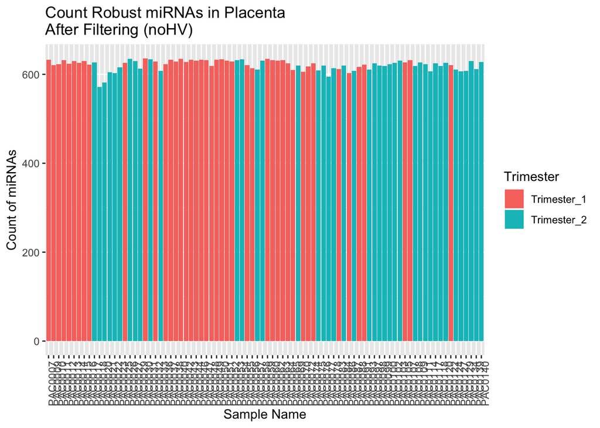

```r
# function to count the number of 'non-zero' (ie expressed) miRNAs
nonzero <- function(x) sum(x != 0)

# count the number of 'non-zero' miRNAs for each sample after filtering
filteredNonZero_noHV <- t(numcolwise(nonzero)(data.frame(DGEList_placenta_noHV[[1]]))) %>%
  as.data.frame() %>%
  tibble::rownames_to_column()

# count the number of 'non-zero' miRNAs for each sample after filtering
filteredNonZero_noHV_preFilter <- t(numcolwise(nonzero)(data.frame(countsPlacenta_noHV))) %>%
  as.data.frame() %>%
  tibble::rownames_to_column()

ggplot(data = filteredNonZero_noHV, aes(x = rowname, y = V1, fill = samples_noHV$group)) +
  geom_bar(stat = "identity") +
  theme(axis.text.x = element_text(angle = 90, hjust = 1)) +
  labs(x = "Sample Name",
       y = "Count of miRNAs",
       title = "Count Robust miRNAs in Placenta \nAfter Filtering (noHV)") +
  # geom_hline(yintercept=770,linetype = "dashed") +
  # geom_text(aes(12, 770, label = "770 Total miRNA"), size = 3, colour = "black") +
  scale_fill_discrete(name = "Trimester")
```

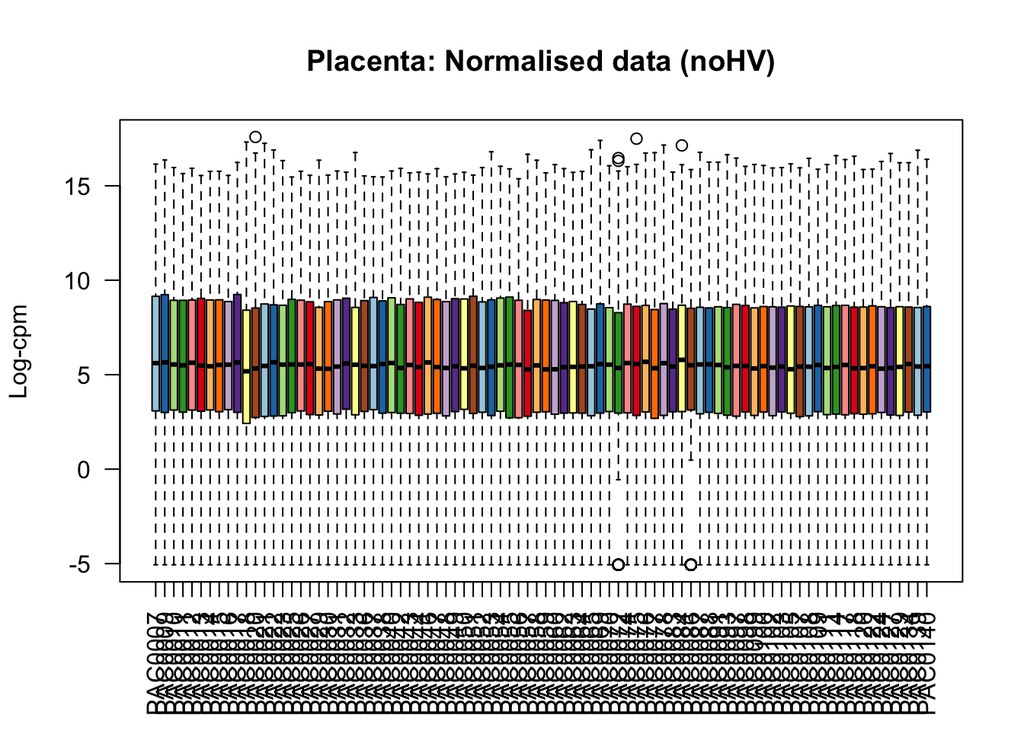

```r
# Distribution of normalised and filtered counts data
lcpm_noHV <- cpm(DGEList_placenta_noHV, log = TRUE)
boxplot(lcpm_noHV, las = 2, col = col, main = "")
title(main = "Placenta: Normalised data (noHV)",ylab = "Log-cpm")
```

# MDS Plots

The multidimensional scaling plots create a temp. log fold change between pairs.  
Here we see that the Leading logFC on dimension 1 seperates the samples by batch indicating the need for batch correction.

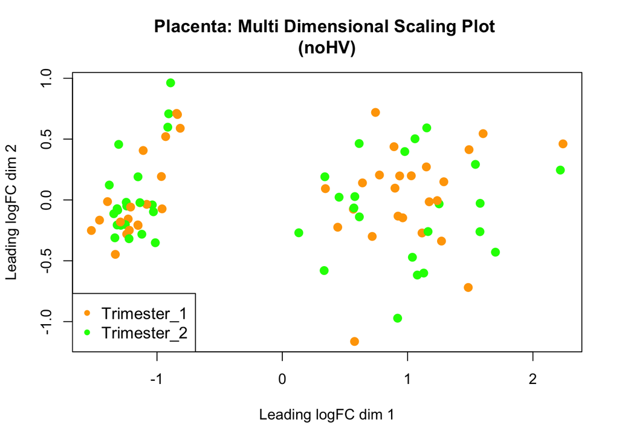

```r
par(mfrow=c(1,1))
#
# # create a table of log counts per million
# lcpm_noHV <- cpm(DGEList_placenta_noHV, log = TRUE, prior.count = 1)

plotMDS(cpm(DGEList_placenta_noHV, log = TRUE),
        col = c("orange", "green"), pch = 20, cex = 1.8)
legend("bottomleft", legend = levels(samples_noHV$group), pch = 20,
       col = c("orange", "green"), ncol = 1, cex = 1.1)
title(main = "Placenta: Multi Dimensional Scaling Plot \n(noHV)")
```

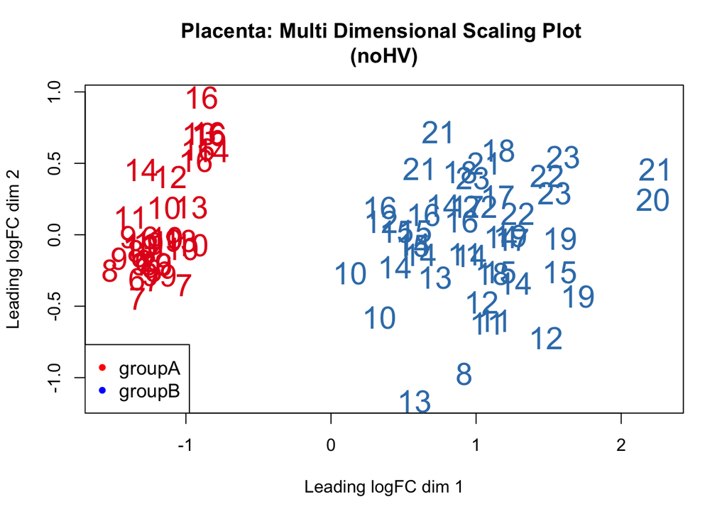

```r
col.process <- samples_noHV$processGroup
levels(col.process) <- brewer.pal(nlevels(col.process), "Set1")
col.process <- as.character(col.process)

plotMDS(cpm(DGEList_placenta_noHV, log = TRUE), dim.plot = c(1,2),
        labels = samples_noHV$gestationalAge, col = col.process,
        pch = 20, cex = 1.8)
legend("bottomleft", legend = levels(samples_noHV$processGroup),
       pch = 20, col = c("red", "blue"), ncol = 1, cex = 1.1)
title(main = "Placenta: Multi Dimensional Scaling Plot \n(noHV)")
```

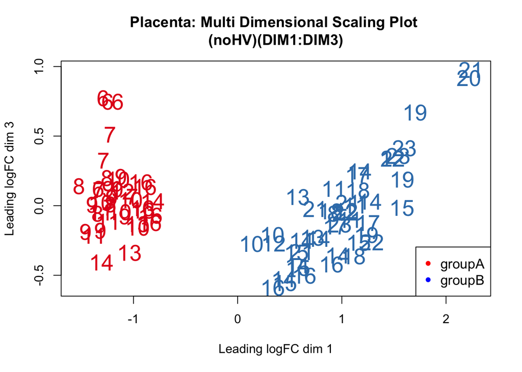

```r
plotMDS(cpm(DGEList_placenta_noHV, log = TRUE), dim.plot = c(1,3),
        labels = samples_noHV$gestationalAge, col = col.process,
        pch = 20, cex = 1.8)
legend("bottomright", legend = levels(samples_noHV$processGroup),
       pch = 20, col = c("red", "blue"), ncol = 1, cex = 1.1)
title(main = "Placenta: Multi Dimensional Scaling Plot \n(noHV)(DIM1:DIM3)")
```

# Sex Independent Differential Expression Analysis - Oxygen (no dijoxin):

- Option 1: Factorial formula and no contrast A nested factorial model allows you to compare groups within each sex. This achieves the aim of treating the two sexes separately:

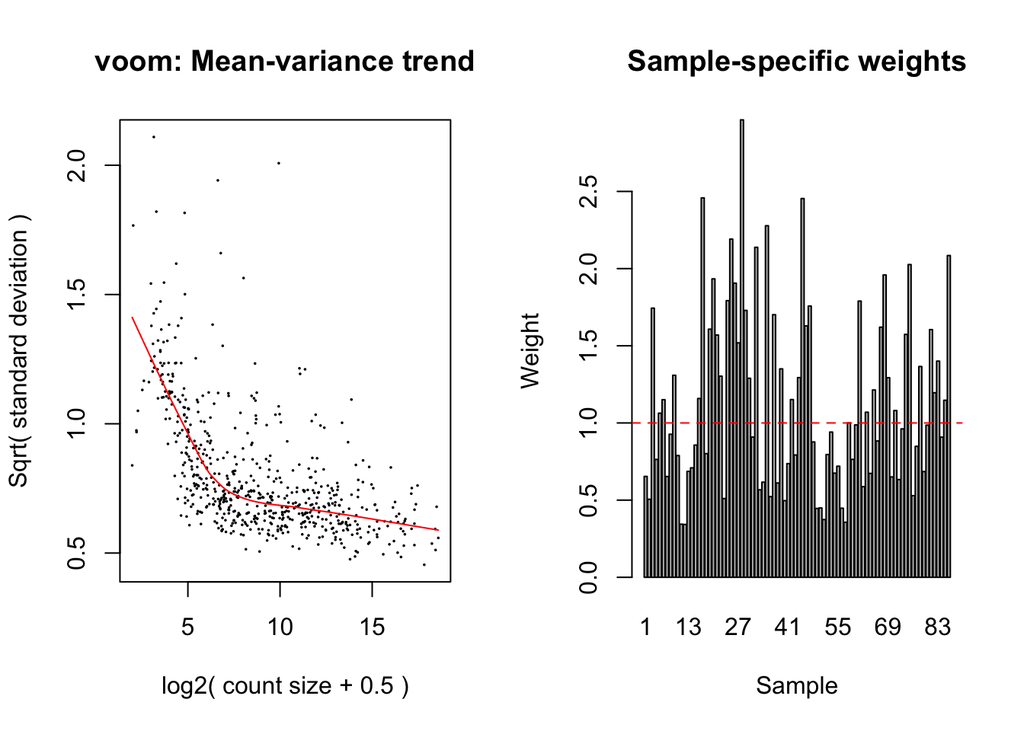

```r
# design to test DE between T1 and T2 looking at female and male baring pregnancies seperately
design_independent_oxygenation <- model.matrix(~ updatedFetalSex +
                                                 updatedFetalSex:oxygenation +
                                                 processGroup,
                                               data = samples_noHV)

voom_independent_oxygenation <- voomWithQualityWeights(DGEList_placenta_noHV,
                                                       design_independent_oxygenation, plot=TRUE)
```

```r
fit_independent_oxygenation <- lmFit(voom_independent_oxygenation,
                                     design_independent_oxygenation)
fit_independent_oxygenation <- eBayes(fit_independent_oxygenation)
summary(decideTests(fit_independent_oxygenation)) # before FDR correction
```

```
##        (Intercept) updatedFetalSexXY processGroupgroupB
## Down            11                32                286
## NotSig          18               567                 76
## Up             608                38                275
##        updatedFetalSexXX:oxygenationoxygenated
## Down                                       113
## NotSig                                     369
## Up                                         155
##        updatedFetalSexXY:oxygenationoxygenated
## Down                                       150
## NotSig                                     302
## Up                                         185
```

## Female Tests - Pre versus Post maternal blood flow

```r
topTable_female_oxygenation <- topTable(fit_independent_oxygenation,
                                        coef = 4,
                                        n = Inf,
                                        sort = "p",
                                        p = 0.05,
                                        adjust.method = "fdr") # trimester 2 vs trimester 1 for females

AllTable_female_oxygenation <- topTable(fit_independent_oxygenation,
                                        coef = 4,
                                        n = Inf,
                                        sort = "p")
```

### Create LaTeX code for the independent fetalSex:Oxygen DE table (Female)

```
## [1] 34
```

```
## [1] 40
```

There are 34 down regulated and 40 up regulated miRNA that pass both the FDR and logFC filters.

## Regression QC plots - fetalSex independent oxygen comparison (Female)

- The distribution of p-values, logFC and the t-stastic are commensurate with this being a valid regression.

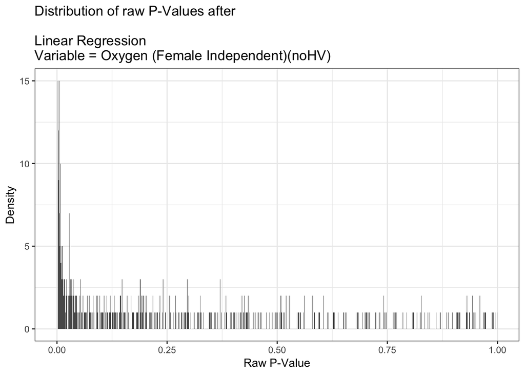

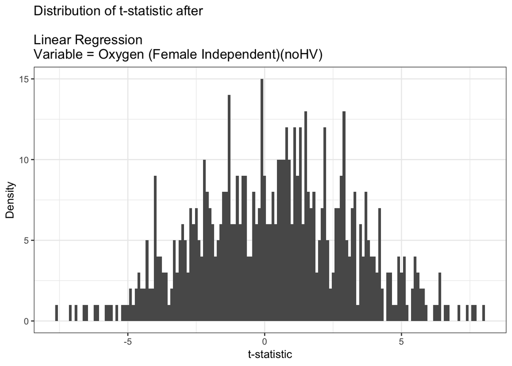

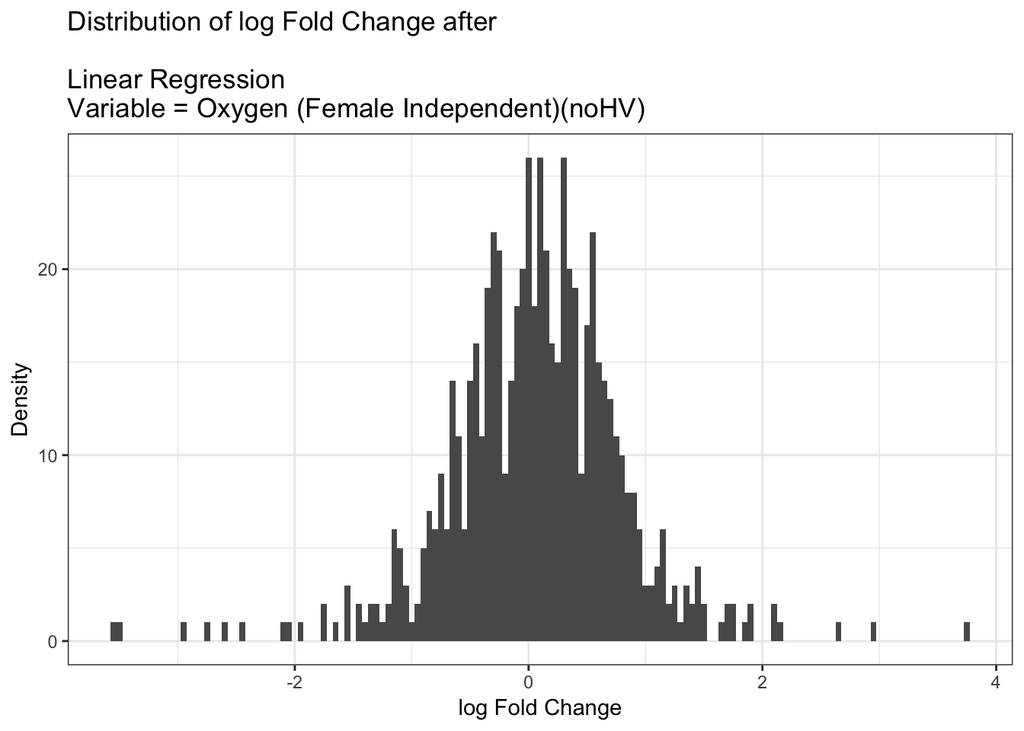

## Volcano plot - Oxygen (Female)

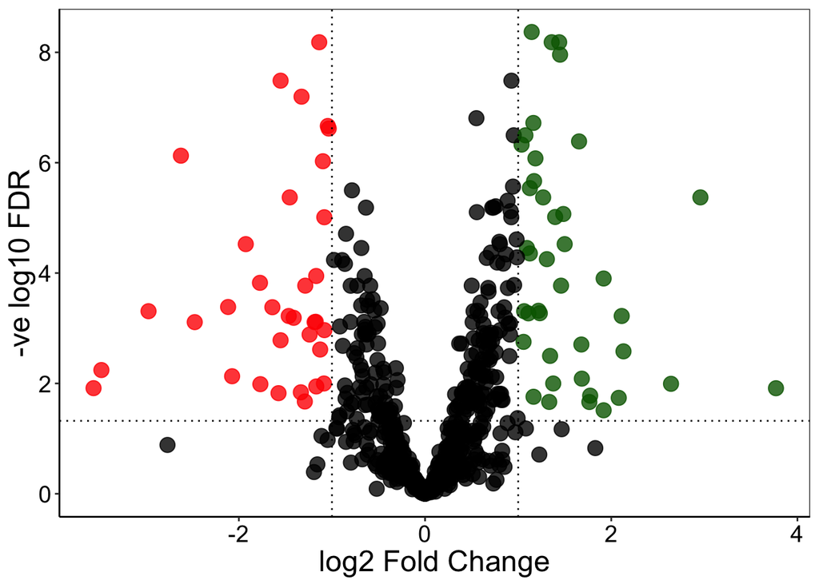

## Male Tests - Pre versus Post maternal blood flow

```r
topTable_male_oxygenation <- topTable(fit_independent_oxygenation,
                                      coef = 5,
                                      n = Inf,
                                      sort = "p",
                                      p = 0.05,
                                      adjust.method = "fdr") # trimester 2 vs trimester 1 for males

AllTable_male_oxygenation <- topTable(fit_independent_oxygenation,
                                      coef = 5,
                                      n = Inf,
                                      sort = "p")
```

### Create LaTeX code for the independent fetalSex:Oxygen DE table (Male)

```
## [1] 24
```

```
## [1] 24
```

There are 24 down regulated and 24 up regulated miRNA that pass both the FDR and logFC filters.

## Regression QC plots - fetalSex independent Oxygen comparison (Male)

- The distribution of p-values, logFC and the t-stastic are commensurate with this being a valid regression.

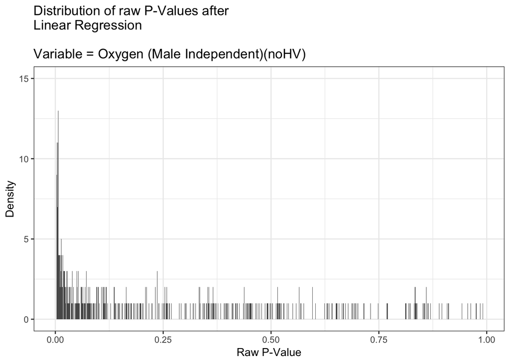

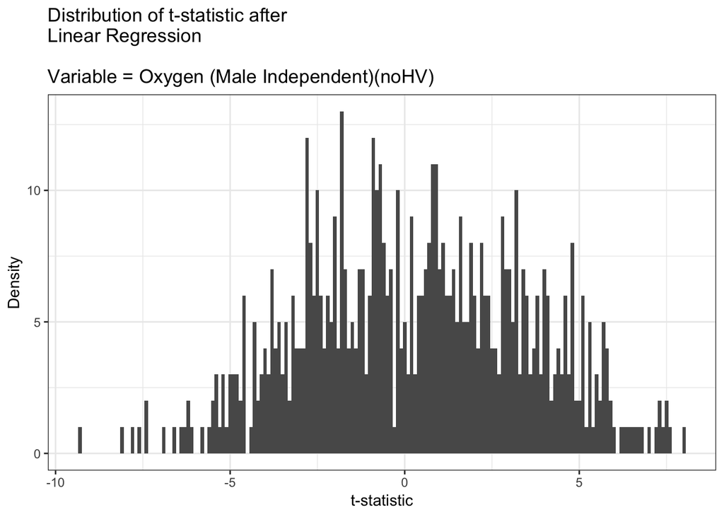

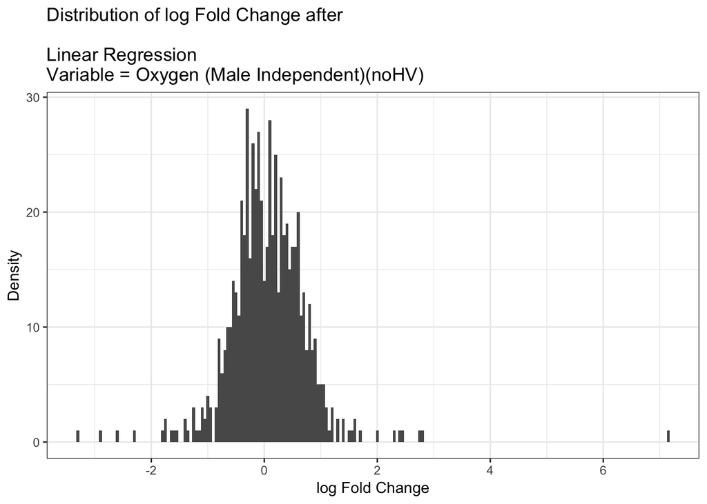

## Volcano plot - Oxygen (Male)

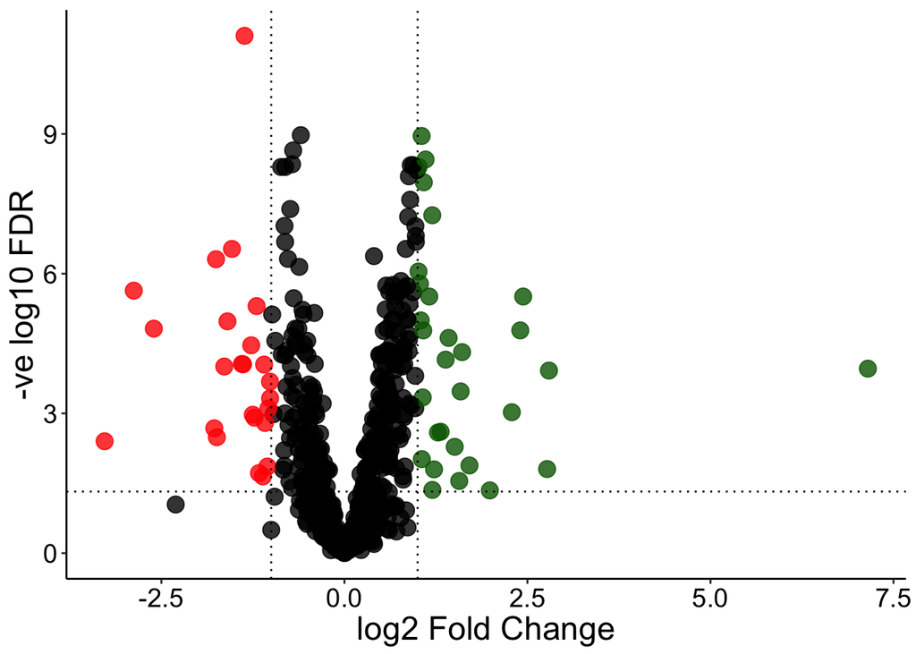

# Scatter plot of logFC for the regresion model <=10 v > 10 indepedent for each fetal sex (control for sequencing batch)

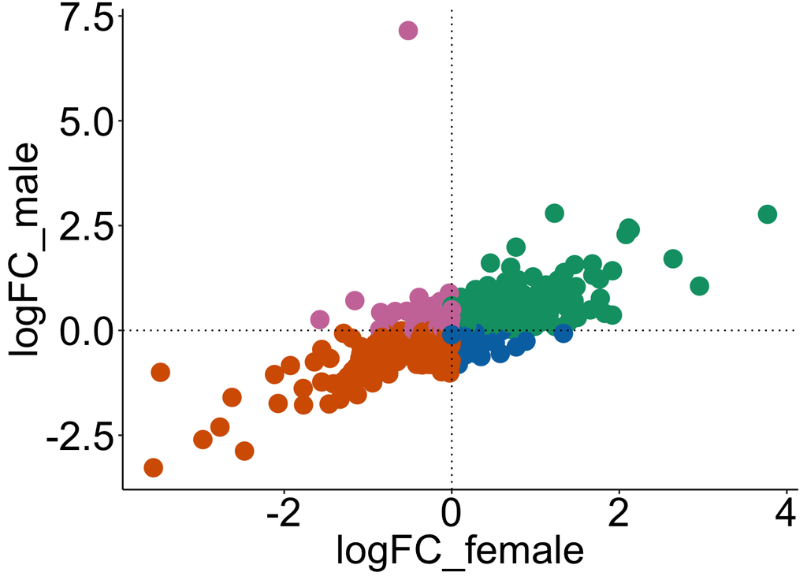

```r
logFC_plot <- AllTable_female_oxygenation %>%
  full_join(., AllTable_male_oxygenation, by = "SYMBOL") %>%
  dplyr::select(., SYMBOL, logFC_female = logFC.x, logFC_male = logFC.y, AveExpr.x)

# adds logical test to assign a colour to each quadrant of the scatter plot
logFC_plot$colour <- ifelse(
                            logFC_plot$logFC_female < 0 & logFC_plot$logFC_male < 0, "#D55E00", # orange
                      ifelse(
                            logFC_plot$logFC_female > 0 & logFC_plot$logFC_male > 0, "#009E73", # green
                      ifelse(
                            logFC_plot$logFC_female < 0 & logFC_plot$logFC_male > 0, "#CC79A7", # kinda purple
                      ifelse(
                            logFC_plot$logFC_female > 0 & logFC_plot$logFC_male < 0, "#0072B2", NA)))) # blue

# Scatter plot of the logFC for the with and without dijoxin regression models
ggplot(data = logFC_plot, aes(x = logFC_female, y = logFC_male)) +
  geom_point(colour = logFC_plot$colour, size = 5) +
  # ggtitle("Scatter plot of logFC: regression models DE T1:T2 male and female") +
  geom_hline(yintercept = 0, linetype = "dotted") +
  geom_vline(xintercept = 0, linetype = "dotted") +
  # geom_text(x = 2, y = 2, label = "logFC +ve in both models") +
  # geom_text(x = -2, y = -2, label = "logFC -ve in both models") +
  # geom_text(x = 2, y = -2, label = "logFC +ve in female -ve in male") +
  # geom_text(x = -2, y = 2, label = "logFC -ve in female +ve in male") +
  # theme_light() +
  theme(text = element_text(size = 25, colour = "black"),
        axis.text = element_text(size = 25, colour = "black")) +
  theme(legend.position = "none") + # take out the legend for the poster
  theme(panel.grid.major = element_blank(), panel.grid.minor = element_blank(),
  panel.background = element_blank(), axis.line = element_line(colour = "black"))
```

```r
posFemNegMas <- filter(logFC_plot, colour == "#0072B2") %>%
  left_join(., AllTable_female_oxygenation, by = "SYMBOL") %>%
  filter(., adj.P.Val < .05)

negFemPosMas <- filter(logFC_plot, colour == "#CC79A7") %>%
  left_join(., AllTable_female_oxygenation, by = "SYMBOL") %>%
  filter(., adj.P.Val < .05)
```

# Import corrected counts for plotting

```r
correctedExpression_noHV <- readRDS(here("cleanData", "correctedExpression_gestationModel.rds"))

# new table with only samplename and week -> makes things easier later
sampleWeek <- samples_noHV %>%
  dplyr::select(., samplename, gestationalAge)

sampleSex <- samples_noHV %>%
  dplyr::select(., samplename, updatedFetalSex, gestationalAge)

# convert the counts table into counts by week using the UDF expressionByWeek
count_by_week <- expressionByWeek(correctedExpression_noHV, samples_noHV)
```

## hsa-miR-29c-3p

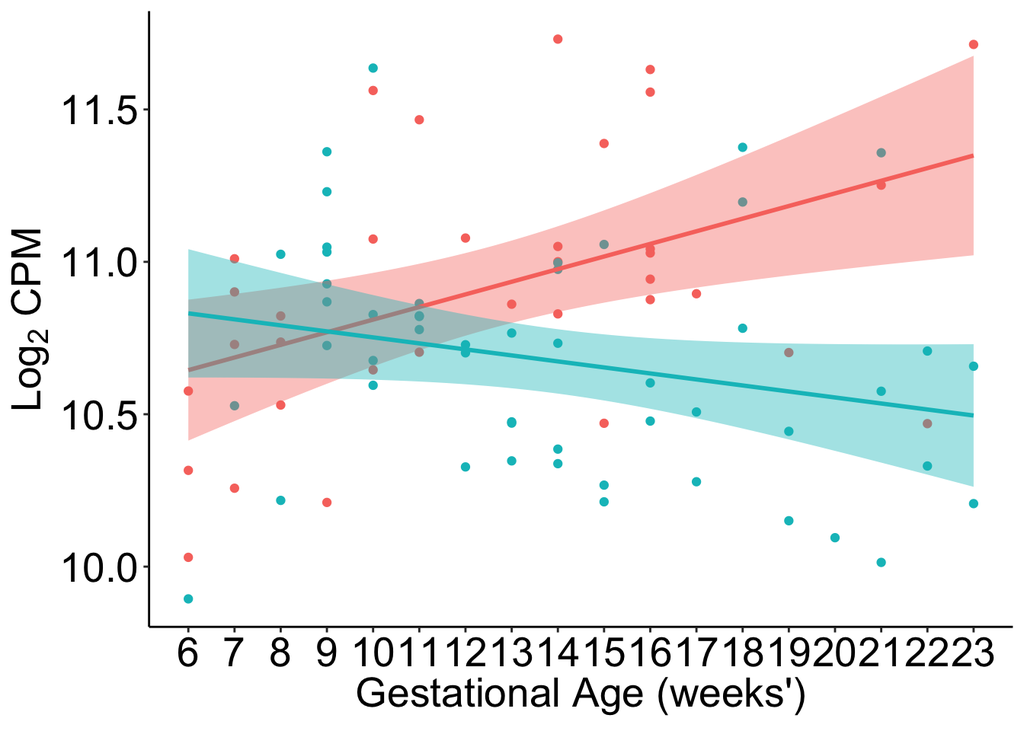

```r
# plot expression of hsa-miR-29c-3p across gestation
# highly expressed miR with sig +ve logFC in female and sig -ve in male

hsa_miR_29c_3p <- 'hsa-miR-29c-3p'
# create new table of counts normalised for library size + TMM normalisation
miR_29c_3p <- data.frame(correctedExpression_noHV) %>%
  tibble::rownames_to_column() %>%
  filter(rowname %in% hsa_miR_29c_3p) %>%
  t() %>%
  as.data.frame() %>%
  tibble::rownames_to_column() %>%
  set_colnames(c("samplename", "hsa_miR_29c_3p"))

miR_29c_3p <- miR_29c_3p[-1,] %>%
  left_join(., sampleSex, by = "samplename")

miR_29c_3p$hsa_miR_29c_3p <- as.character(miR_29c_3p$hsa_miR_29c_3p)
miR_29c_3p$hsa_miR_29c_3p <- as.numeric(miR_29c_3p$hsa_miR_29c_3p)

ggplot(data = miR_29c_3p, aes(x = gestationalAge, y = hsa_miR_29c_3p, colour = updatedFetalSex)) +
  geom_point() +
  scale_x_continuous(breaks = c(6, 7, 8, 9, 10, 11, 12, 13, 14, 15, 16, 17, 18, 19, 20, 21, 22, 23)) +
  geom_smooth(method = lm, aes(fill = updatedFetalSex)) +
  # theme_bw() +
  theme(text = element_text(size = 20, colour = "black"),
        axis.text = element_text(size = 20, colour = "black")) +
  labs(x = expression(paste("Gestational Age (weeks')")),
                  y = expression(paste("Log"[2], " CPM"))) +
  theme(legend.position = "none") + # take out the legend for the poster
  theme(panel.grid.major = element_blank(), panel.grid.minor = element_blank(),
  panel.background = element_blank(), axis.line = element_line(colour = "black"))
```

## hsa-miR-15b-5p

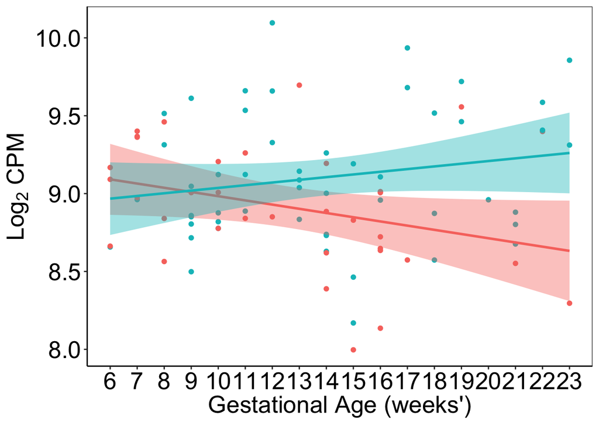

```r
# plot expression of hsa-miR-15b-5p across gestation
# highly expressed miR with sig -ve logFC in female and sig +ve in male

hsa_miR_15b_5p <- 'hsa-miR-15b-5p'
# create new table of counts normalised for library size + TMM normalisation
miR_15b_5p <- data.frame(correctedExpression_noHV) %>%
  tibble::rownames_to_column() %>%
  filter(rowname %in% hsa_miR_15b_5p) %>%
  t() %>%
  as.data.frame() %>%
  tibble::rownames_to_column() %>%
  set_colnames(c("samplename", "hsa_miR_15b_5p"))

miR_15b_5p <- miR_15b_5p[-1,] %>%
  left_join(., sampleSex, by = "samplename")

miR_15b_5p$hsa_miR_15b_5p <- as.character(miR_15b_5p$hsa_miR_15b_5p)
miR_15b_5p$hsa_miR_15b_5p <- as.numeric(miR_15b_5p$hsa_miR_15b_5p)

ggplot(data = miR_15b_5p, aes(x = gestationalAge, y = hsa_miR_15b_5p, colour = updatedFetalSex)) +
  geom_point() +
  scale_x_continuous(breaks = c(6, 7, 8, 9, 10, 11, 12, 13, 14, 15, 16, 17, 18, 19, 20, 21, 22, 23)) +
  geom_smooth(method = lm, aes(fill = updatedFetalSex)) +
  theme_bw() +
  theme(text = element_text(size = 20, colour = "black"),
        axis.text = element_text(size = 20, colour = "black")) +
  labs(x = expression(paste("Gestational Age (weeks')")),
                  y = expression(paste("Log"[2], " CPM"))) +
  theme(legend.position = "none") + # take out the legend for the poster
  theme(panel.grid.major = element_blank(), panel.grid.minor = element_blank(),
  panel.background = element_blank(), axis.line = element_line(colour = "black"))
```

# Establish the universe of genes

```r
# set up the placenta gene universe
## Import RNAseq DE table

LOEvNOE_DE_table <- read_tsv(here("cleanData/LOEvNOE_DE_table.tsv"),
                             col_names = TRUE)

# factor vector of all genes identified in placenta, duplicates removed.
universe <- na.omit(LOEvNOE_DE_table)
universe <- universe[!duplicated(universe$Symbol), ]
universe <- universe[!duplicated(universe$entrezgene), ]

universe <- as.factor(universe$entrezgene)
```

## Import Counts and Sample Data

```r
# import the limma corrected expression data
correctedExpression_noHV <- readRDS(here("cleanData/correctedExpression_gestationModel.rds")) %>%
  as.data.frame() %>%
       dplyr::select(., -c(PAC0025,PAC0036)) # remove PAC0071 and PAC0131 - low reads
```

## Import RNASeq Count Data

```r
# Import RNAseq's counts table
RNAcounts <- read.table(here("cleanData/NIH_terminations_firstSecond.counts.tsv"),
                             sep = "\t",
                             header = TRUE,
                             row.names = "Geneid")

# create a variable for the list of hyper variable samples (36 and 34 removed for consistency between RNAseq and miRseq)
hyperVariableSamples <- c("PAC006", "PAC008", "PAC024", "PAC025", "PAC034", "PAC035", "PAC039", "PAC041", "PAC036", "PAC045", "PAC071", "PAC131")

# remove HV samples from the counts data
RNAcounts_noHV <- RNAcounts %>%
  dplyr::select(., -(hyperVariableSamples))

# replace the PAC006 naming convention with the PAC0006 naming convention (same as the miRNAseq)
names(RNAcounts_noHV) <- colnames(correctedExpression_noHV)

lcpm_RNA_noHV <- readRDS(here("cleanData/lcpm_RNA_noHV.Rds"))
```

## Download mart data

```r
# add the grch37 host so that I get the hg19/GRCh37 gene IDs
grch37 <- useMart(biomart="ENSEMBL_MART_ENSEMBL",
                  host="grch37.ensembl.org",
                  path="/biomart/martservice",
                  dataset="hsapiens_gene_ensembl")

# check the list for attributes to ensure correct nomenclature
# listAttributes(grch37)

# pull down the data from Biomart
martData_transcript <- getBM(mart = grch37,
                  attributes = c("ensembl_gene_id",
                                 "external_gene_name",
                                 "entrezgene_id",
                                 "ensembl_transcript_id_version"),
                  filters = "ensembl_gene_id",
                  values = rownames(RNAcounts_noHV))

martData <- getBM(mart = grch37,
                  attributes = c("ensembl_gene_id",
                                 "external_gene_name",
                                 "entrezgene_id",
                                 "gene_biotype"),
                  filters = "ensembl_gene_id",
                  values = rownames(RNAcounts_noHV)) # include on genes from placenta counts
```

## Correlation data

```r
# create correlation matrix
correlation_miRNA_mRNA <- cor(t(rbind(lcpm_RNA_noHV, correctedExpression_noHV)), method = "pearson")

# pinpoin the miRNA row
miRNA_start <- nrow(lcpm_RNA_noHV) + 1

# create correlation table
correlation <- correlation_miRNA_mRNA[1:nrow(lcpm_RNA_noHV), miRNA_start:ncol(correlation_miRNA_mRNA)]
```

## ENST level information

```r
# TargetScan uses the ENST transcript level identifiers so I need to convert the ENSG ID's in the count matrix
# This solution is problematic because it forces row duplication (genes have more than one transcript)
# not sure what to do about this but will speak with Jimmy

RNAcounts_noHV_ENST <- RNAcounts_noHV %>%
  tibble::rownames_to_column() %>%
  dplyr::select(., ensembl_gene_id = rowname, everything()) %>%
  left_join(., martData_transcript, by = "ensembl_gene_id") %>%
  dplyr::select(ensembl_gene_id, ensembl_transcript_id_version, everything())

RNAcounts_noHV_ext <- RNAcounts_noHV %>%
  tibble::rownames_to_column() %>%
  dplyr::select(., ensembl_gene_id = rowname, everything()) %>%
  left_join(., martData, by = "ensembl_gene_id") %>%
  dplyr::select(ensembl_gene_id, external_gene_name, entrezgene_id, gene_biotype, everything())
```

# hsa-miR-29c-3p

## hsa-miR-29c-3p: Create table of highly correlated mRNA

## perform goana analysis

```r
# Which genes are high correlated with my miRNA of interest
goana_miR_29c_3p_all <- dplyr::select(as.data.frame(correlation), `hsa-miR-29c-3p`) %>%
  tibble::rownames_to_column() %>% # so we don't loose the gene IDs
  filter(., `hsa-miR-29c-3p` <= -0.5) %>% # only keep correlations <= -0.5 ie highly negatively correlated
  dplyr::select(., ensembl_gene_id = rowname, everything())  %>% # rename the gene ID column ready to join
  left_join(., martData[, c("ensembl_gene_id", "entrezgene_id")], by = "ensembl_gene_id") %>%
  distinct(., entrezgene_id, .keep_all = TRUE)

# Run goana GO analysis on highly correlated genes
goana_correlated_29c_3p <- goana(goana_miR_29c_3p_all$entrezgene,
                         species = "Hs")
topGO_correlated_29c_3p <- topGO(goana_correlated_29c_3p,
                         number = Inf) %>%
  filter(., P.DE <= 0.01) %>%
  mutate(., GeneRatio = DE/N*100)

pander(topGO_correlated_29c_3p)
```

| Term | Ont | N | DE | P.DE | GeneRatio |
| --- | --- | --- | --- | --- | --- |
| U2-type catalytic step 2 spliceosome | CC | 29 | 2 | 3.206e-05 | 6.897 |
| mRNA splicing, via spliceosome | BP | 326 | 3 | 8.98e-05 | 0.9202 |
| RNA splicing, via transesterification reactions with bulged adenosine as nucleophile | BP | 326 | 3 | 8.98e-05 | 0.9202 |
| RNA splicing, via transesterification reactions | BP | 329 | 3 | 9.228e-05 | 0.9119 |
| U2-type spliceosomal complex | CC | 60 | 2 | 0.0001392 | 3.333 |
| RNA splicing | BP | 432 | 3 | 0.0002069 | 0.6944 |
| Krueppel-associated box domain binding | MF | 1 | 1 | 0.0003084 | 100 |
| mRNA processing | BP | 495 | 3 | 0.0003092 | 0.6061 |
| protein sumoylation | BP | 95 | 2 | 0.0003494 | 2.105 |
| catalytic step 2 spliceosome | CC | 101 | 2 | 0.0003948 | 1.98 |
| generation of catalytic spliceosome for first transesterification step | BP | 2 | 1 | 0.0006167 | 50 |
| regulation of lysosomal membrane permeability | BP | 2 | 1 | 0.0006167 | 50 |
| regulation of gene silencing | BP | 133 | 2 | 0.0006833 | 1.504 |
| lysosomal membrane organization | BP | 3 | 1 | 0.0009249 | 33.33 |
| negative regulation of DNA demethylation | BP | 3 | 1 | 0.0009249 | 33.33 |
| negative regulation of lysosomal protein catabolic process | BP | 3 | 1 | 0.0009249 | 33.33 |
| negative regulation of protein catabolic process in the vacuole | BP | 3 | 1 | 0.0009249 | 33.33 |
| regulation of lysosome organization | BP | 3 | 1 | 0.0009249 | 33.33 |
| viral process | BP | 785 | 3 | 0.001194 | 0.3822 |
| glomerular visceral epithelial cell migration | BP | 4 | 1 | 0.001233 | 25 |
| multivesicular body, internal vesicle | CC | 4 | 1 | 0.001233 | 25 |
| negative regulation of transforming growth factor beta1 production | BP | 4 | 1 | 0.001233 | 25 |
| positive regulation of methylation-dependent chromatin silencing | BP | 4 | 1 | 0.001233 | 25 |
| regulation of genetic imprinting | BP | 4 | 1 | 0.001233 | 25 |
| mRNA metabolic process | BP | 826 | 3 | 0.001385 | 0.3632 |
| spliceosomal complex | CC | 190 | 2 | 0.001387 | 1.053 |
| viral gene expression | BP | 190 | 2 | 0.001387 | 1.053 |
| symbiont process | BP | 845 | 3 | 0.001479 | 0.355 |
| spliceosomal conformational changes to generate catalytic conformation | BP | 5 | 1 | 0.001541 | 20 |
| interspecies interaction between organisms | BP | 888 | 3 | 0.001708 | 0.3378 |

[output cut: 82 more lines]

## hsa-miR-29c-3p: Import TargetScan targets

## perform goana analysis

```r
# Which genes are predicted to be targets
targetscan_miR_29c_3p_all <- read_delim(here("cleanData/TargetScan/miR_29_3p_predicted_targets.txt"),
                                        delim = "\t")

targetscan_miR_29c_3p <-  arrange(targetscan_miR_29c_3p_all, `Total context++ score`) %>%
  .[1:(as.integer(dim(targetscan_miR_29c_3p_all)[[1]]*.1)),] %>%
  left_join(., martData_transcript, by = c(`Representative transcript` = "ensembl_transcript_id_version"))

# Run goana GO analysis on highly correlated genes
goana_targetscan_29c_3p <- goana(targetscan_miR_29c_3p$entrezgene_id,
                         species = "Hs")
topGO_targetscan_29c_3p <- topGO(goana_targetscan_29c_3p,
                         number = Inf) %>%
  filter(., P.DE <= 0.01) %>%
  mutate(., GeneRatio = DE/N*100)

pander(topGO_targetscan_29c_3p)
```

| Term | Ont | N | DE | P.DE | GeneRatio |
| --- | --- | --- | --- | --- | --- |
| complex of collagen trimers | CC | 20 | 12 | 3.473e-22 | 60 |
| collagen trimer | CC | 88 | 17 | 7.362e-21 | 19.32 |
| proteinaceous extracellular matrix | CC | 375 | 26 | 9.539e-20 | 6.933 |
| collagen catabolic process | BP | 68 | 15 | 1.84e-19 | 22.06 |
| extracellular matrix structural constituent | MF | 77 | 15 | 1.395e-18 | 19.48 |
| extracellular matrix component | CC | 119 | 17 | 1.662e-18 | 14.29 |
| extracellular matrix | CC | 479 | 26 | 4.005e-17 | 5.428 |
| collagen metabolic process | BP | 124 | 16 | 9.542e-17 | 12.9 |
| extracellular matrix organization | BP | 341 | 22 | 3.852e-16 | 6.452 |
| banded collagen fibril | CC | 12 | 8 | 1.121e-15 | 66.67 |
| fibrillar collagen trimer | CC | 12 | 8 | 1.121e-15 | 66.67 |
| collagen fibril organization | BP | 47 | 11 | 7.042e-15 | 23.4 |
| extracellular structure organization | BP | 395 | 22 | 8.152e-15 | 5.57 |
| platelet-derived growth factor binding | MF | 11 | 6 | 2.804e-11 | 54.55 |
| endoplasmic reticulum lumen | CC | 297 | 16 | 8.121e-11 | 5.387 |
| basement membrane | CC | 92 | 10 | 3.847e-10 | 10.87 |
| basement membrane collagen trimer | CC | 8 | 4 | 1.114e-07 | 50 |
| circulatory system development | BP | 1105 | 24 | 1.281e-07 | 2.172 |
| structural molecule activity | MF | 731 | 19 | 2.129e-07 | 2.599 |
| 5-methylcytosine catabolic process | BP | 3 | 3 | 2.589e-07 | 100 |
| 5-methylcytosine metabolic process | BP | 3 | 3 | 2.589e-07 | 100 |
| collagen type V trimer | CC | 3 | 3 | 2.589e-07 | 100 |
| heart development | BP | 550 | 16 | 4.856e-07 | 2.909 |
| methylcytosine dioxygenase activity | MF | 4 | 3 | 1.031e-06 | 75 |
| blood vessel development | BP | 736 | 18 | 1.106e-06 | 2.446 |
| vasculature development | BP | 761 | 18 | 1.777e-06 | 2.365 |
| multicellular organism development | BP | 5351 | 59 | 1.975e-06 | 1.103 |
| cardiovascular system development | BP | 769 | 18 | 2.06e-06 | 2.341 |
| oxidative demethylation | BP | 15 | 4 | 2.098e-06 | 26.67 |
| embryo development | BP | 959 | 20 | 3.081e-06 | 2.086 |

[output cut: 221 more lines]

# hsa-miR-15b-5p

## hsa-miR-15b-5p: Create table of highly correlated mRNA

## perform goana analysis

```r
# Which genes are high correlated with my miRNA of interest
goana_miR_15b_5p_all <- dplyr::select(as.data.frame(correlation), `hsa-miR-15b-5p`) %>%
  tibble::rownames_to_column() %>% # so we don't loose the gene IDs
  filter(., `hsa-miR-15b-5p` <= -0.5) %>% # only keep correlations <= -0.5 ie highly negatively correlated
  dplyr::select(., ensembl_gene_id = rowname, everything())  %>% # rename the gene ID column ready to join
  left_join(., martData[, c("ensembl_gene_id", "entrezgene_id")], by = "ensembl_gene_id") %>%
  distinct(., entrezgene_id, .keep_all = TRUE)

# Run goana GO analysis on highly correlated genes
goana_correlated_15b_5p <- goana(goana_miR_15b_5p_all$entrezgene,
                         species = "Hs")
topGO_correlated_15b_5p <- topGO(goana_correlated_15b_5p,
                         number = Inf) %>%
  filter(., P.DE <= 0.01) %>%
  mutate(., GeneRatio = DE/N*100)

pander(topGO_correlated_15b_5p)
```

| Term | Ont | N | DE | P.DE | GeneRatio |
| --- | --- | --- | --- | --- | --- |
| box H/ACA RNP complex | CC | 10 | 1 | 0.000514 | 10 |
| small nucleolar ribonucleoprotein complex | CC | 27 | 1 | 0.001388 | 3.704 |

## hsa-miR-15b-5p: Import TargetScan targets

## perform goana analysis

```r
# Which genes are predicted to be targets
targetscan_miR_15b_5p_all <- read_delim(here("cleanData/TargetScan/miR_15_5p_16_5p_195_5p_424_5p_497_5p_predicted_targets.txt"),
                                        delim = "\t")
targetscan_miR_15b_5p <-  arrange(targetscan_miR_15b_5p_all, `Total context++ score`) %>%
# subset out the top 10% by total context score
  .[1:(as.integer(dim(targetscan_miR_15b_5p_all)[[1]]*.1)),] %>%
  left_join(., martData_transcript, by = c(`Representative transcript` = "ensembl_transcript_id_version"))

# Run goana GO analysis on highly correlated genes
goana_targetscan_15b_5p <- goana(targetscan_miR_15b_5p$entrezgene_id,
                         species = "Hs")
topGO_targetscan_15b_5p <- topGO(goana_targetscan_15b_5p,
                         number = Inf) %>%
  filter(., P.DE <= 0.01) %>%
  mutate(., GeneRatio = DE/N*100)

pander(topGO_targetscan_15b_5p)
```

| Term | Ont | N | DE | P.DE | GeneRatio |
| --- | --- | --- | --- | --- | --- |
| positive regulation of cellular process | BP | 5142 | 72 | 5.519e-09 | 1.4 |
| positive regulation of metabolic process | BP | 3329 | 53 | 3.273e-08 | 1.592 |
| cellular protein modification process | BP | 4192 | 60 | 1.286e-07 | 1.431 |
| protein modification process | BP | 4192 | 60 | 1.286e-07 | 1.431 |
| positive regulation of cellular metabolic process | BP | 3074 | 49 | 1.368e-07 | 1.594 |
| positive regulation of macromolecule metabolic process | BP | 3106 | 49 | 1.892e-07 | 1.578 |
| positive regulation of biological process | BP | 5841 | 74 | 2.585e-07 | 1.267 |
| macromolecule modification | BP | 4389 | 61 | 2.787e-07 | 1.39 |
| positive regulation of nitrogen compound metabolic process | BP | 2965 | 47 | 3.298e-07 | 1.585 |
| intracellular organelle | CC | 12604 | 123 | 5.872e-07 | 0.9759 |
| membrane-bounded organelle | CC | 12616 | 123 | 6.331e-07 | 0.975 |
| ubiquitin protein ligase activity | MF | 224 | 11 | 1.183e-06 | 4.911 |
| ubiquitin-like protein ligase activity | MF | 229 | 11 | 1.469e-06 | 4.803 |
| positive regulation of cellular catabolic process | BP | 335 | 13 | 1.756e-06 | 3.881 |
| positive regulation of nucleobase-containing compound metabolic process | BP | 1742 | 32 | 2.127e-06 | 1.837 |
| intracellular | CC | 14673 | 134 | 2.219e-06 | 0.9132 |
| intracellular membrane-bounded organelle | CC | 10864 | 110 | 2.326e-06 | 1.013 |
| ubiquitin-like protein transferase activity | MF | 472 | 15 | 3.266e-06 | 3.178 |
| positive regulation of RNA metabolic process | BP | 1523 | 29 | 3.516e-06 | 1.904 |
| intracellular part | CC | 14395 | 132 | 3.589e-06 | 0.917 |
| organelle | CC | 13597 | 127 | 4.809e-06 | 0.934 |
| protein modification by small protein conjugation | BP | 915 | 21 | 5.998e-06 | 2.295 |
| positive regulation of Wnt signaling pathway | BP | 171 | 9 | 6.531e-06 | 5.263 |
| regulation of cellular protein metabolic process | BP | 2792 | 42 | 6.98e-06 | 1.504 |
| ubiquitin-protein transferase activity | MF | 446 | 14 | 8.116e-06 | 3.139 |
| positive regulation of catabolic process | BP | 393 | 13 | 9.952e-06 | 3.308 |
| positive regulation of canonical Wnt signaling pathway | BP | 137 | 8 | 1.013e-05 | 5.839 |
| ubiquitin-dependent protein catabolic process | BP | 587 | 16 | 1.059e-05 | 2.726 |
| protein modification by small protein conjugation or removal | BP | 1119 | 23 | 1.257e-05 | 2.055 |
| modification-dependent protein catabolic process | BP | 597 | 16 | 1.305e-05 | 2.68 |

[output cut: 320 more lines]